# homework

Michelle

11/3/2021

## Hypothesis testing

“NYC_covid_cases_by_age.csv” contains weekly data of cases in NYC over the course of the pandemic.

1. Import and tidy the data

```r
nyc_cases<- read.csv("NYC_covid_cases_by_age.csv")
nyc_cases_long <- nyc_cases %>% gather("age_group", "cases", -week_ending)
nyc_cases_long$age_group<- as.factor(nyc_cases_long$age_group)
nyc_cases_long$week_ending <- as.Date(nyc_cases_long$week_ending, "%m/%d/%Y")
```

2. Create a plot that shows the trajectory of cases over the course of the pandemic for each of the age groups and for all ages combined. (If you have not already created a dataframe with a long data format, will need to reformat the data to use ggplot.)

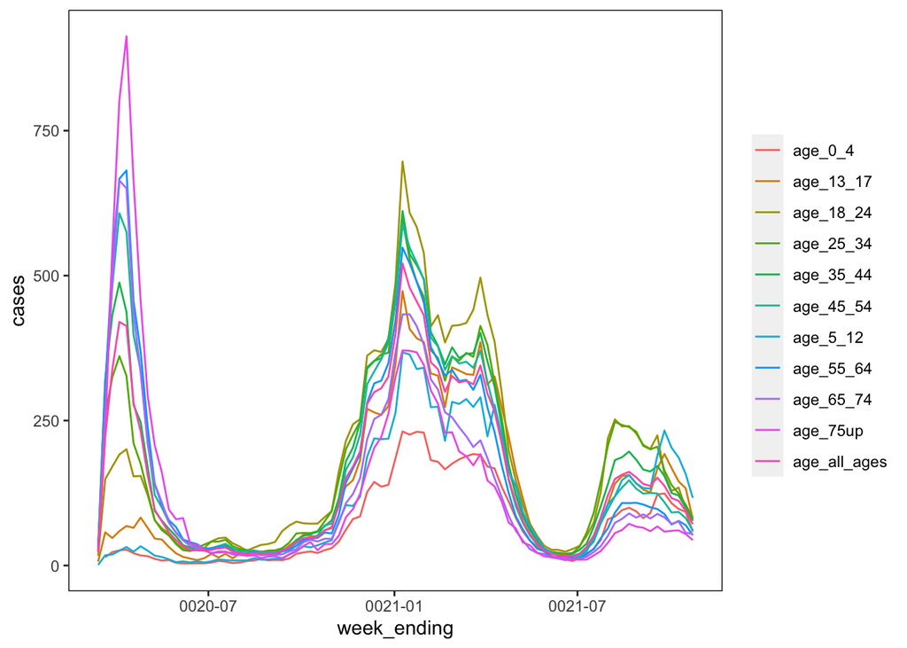

```r
cases_weekly_plot<- ggplot(nyc_cases_long, aes(x=week_ending, y = cases,
                                               color= age_group, group= age_group))+
  geom_line() +
  theme(panel.background=element_blank(),
        strip.background = element_blank(),
        strip.placement = "outside",
        strip.text=element_blank(),
        panel.border=element_rect(colour="black",fill=NA),
        legend.title = element_blank())
cases_weekly_plot
```

How would you determine whether there was a statistically significant difference in cases among people aged 25-34 vs. those aged 75 and over?

First, test for normality. Use histogram and qq plots to visualize the data.

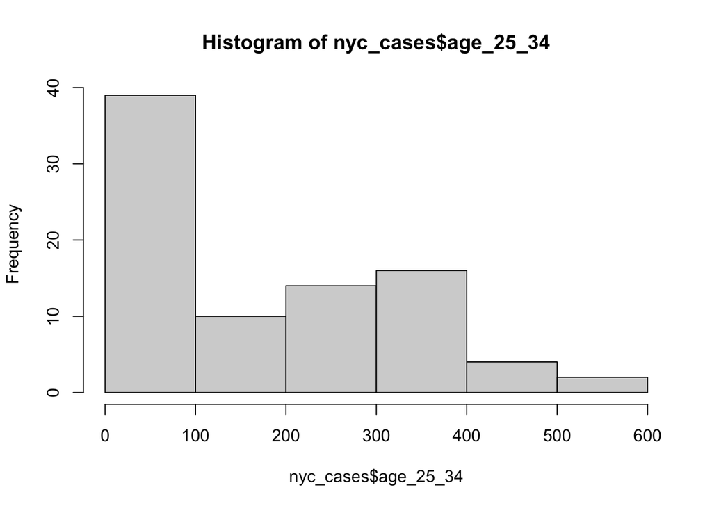

```r
hist(nyc_cases$age_25_34)
```

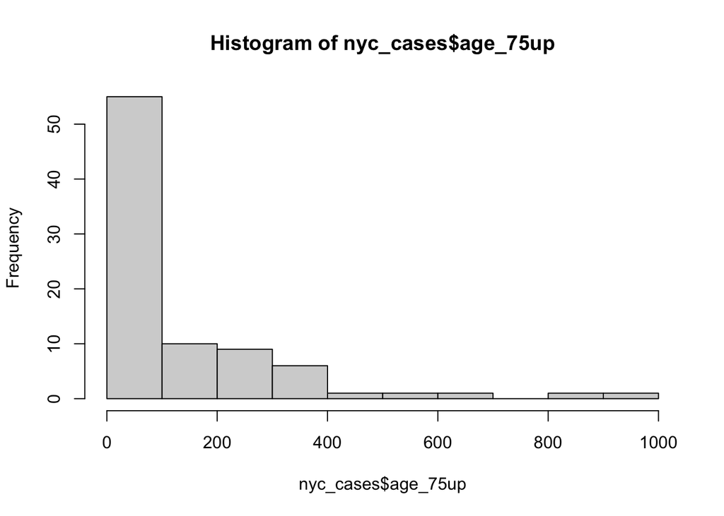

```r
hist(nyc_cases$age_75up)
```

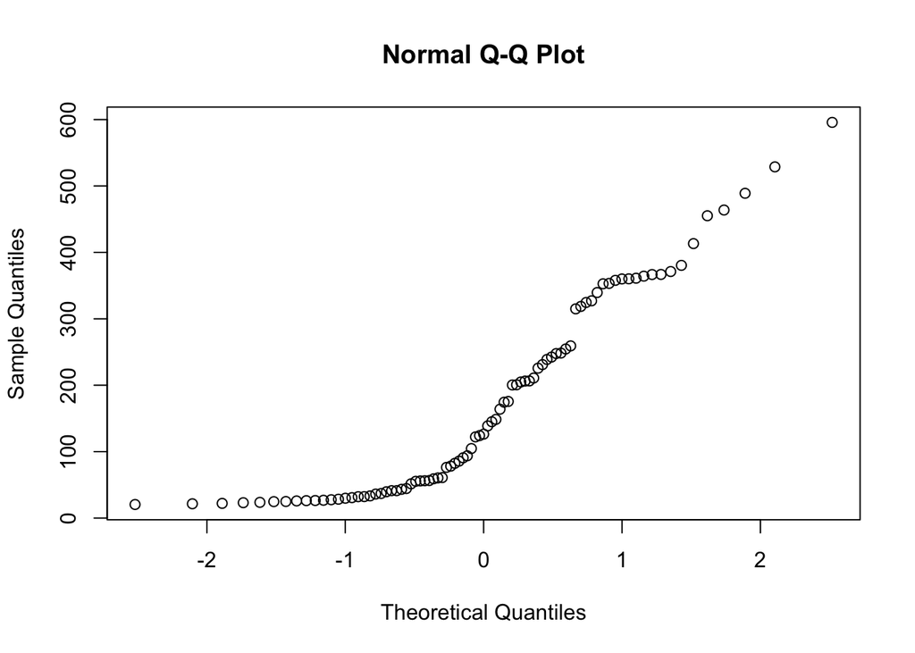

```r
qqnorm(nyc_cases$age_25_34)
```

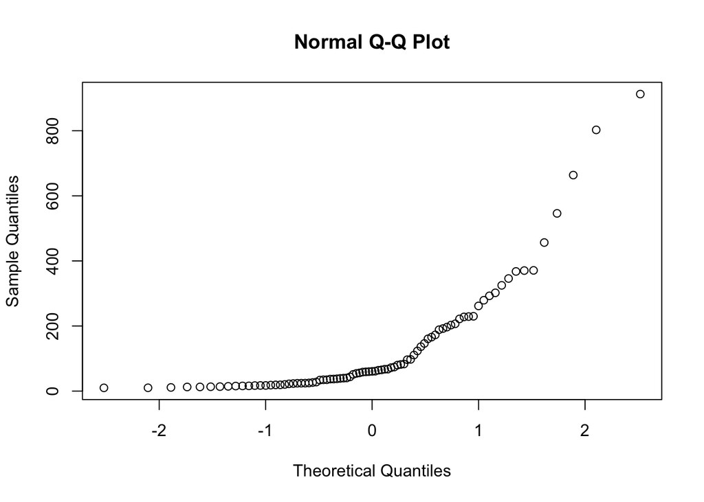

```r
qqnorm(nyc_cases$age_75up)
```

```r
shapiro.test(nyc_cases$age_25_34)
```

```
##
##  Shapiro-Wilk normality test
##
## data:  nyc_cases$age_25_34
## W = 0.87819, p-value = 8.832e-07
```

```r
shapiro.test(nyc_cases$age_75up)
```

```
##
##  Shapiro-Wilk normality test
##
## data:  nyc_cases$age_75up
## W = 0.69847, p-value = 6.386e-12
```

If the data looks highly skewed, it might be useful to normalize the data.

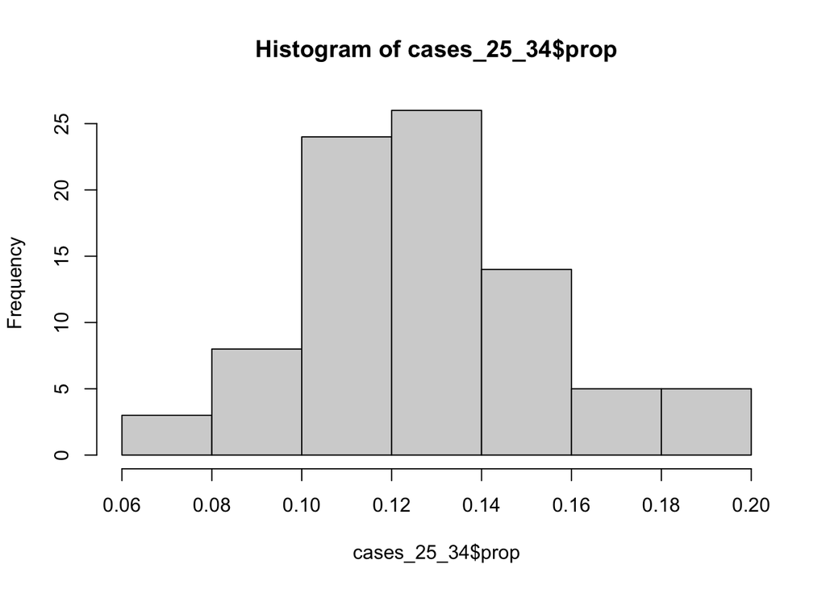

```r
nyc_cases_prop<- nyc_cases_long %>%
  filter(age_group != "age_all_ages")

nyc_cases_prop<- nyc_cases_prop %>%
  drop_na()%>%
  group_by(week_ending) %>%
  mutate(prop = cases/sum(cases))

cases_25_34<-nyc_cases_prop %>%
  filter(age_group == "age_25_34")

cases_75up<-nyc_cases_prop %>%
  filter(age_group == "age_75up")


hist(cases_25_34$prop)
```

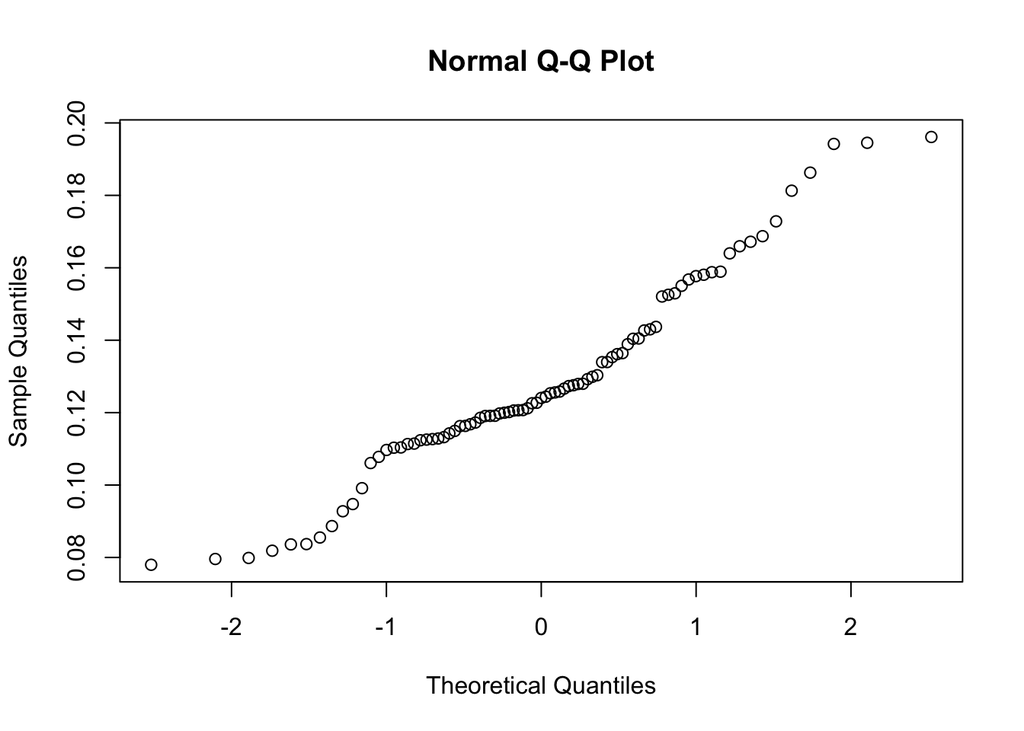

```r
qqnorm(cases_25_34$prop)
```

```r
shapiro.test(cases_25_34$prop)
```

```
##
##  Shapiro-Wilk normality test
##
## data:  cases_25_34$prop
## W = 0.95915, p-value = 0.008741
```

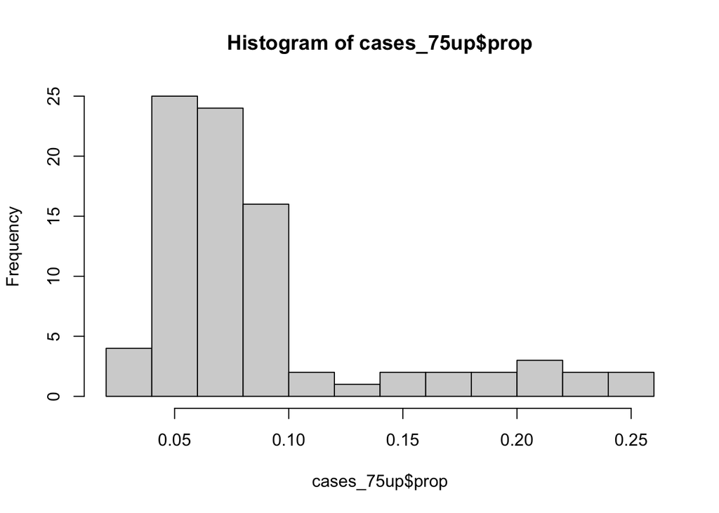

```r
hist(cases_75up$prop)
```

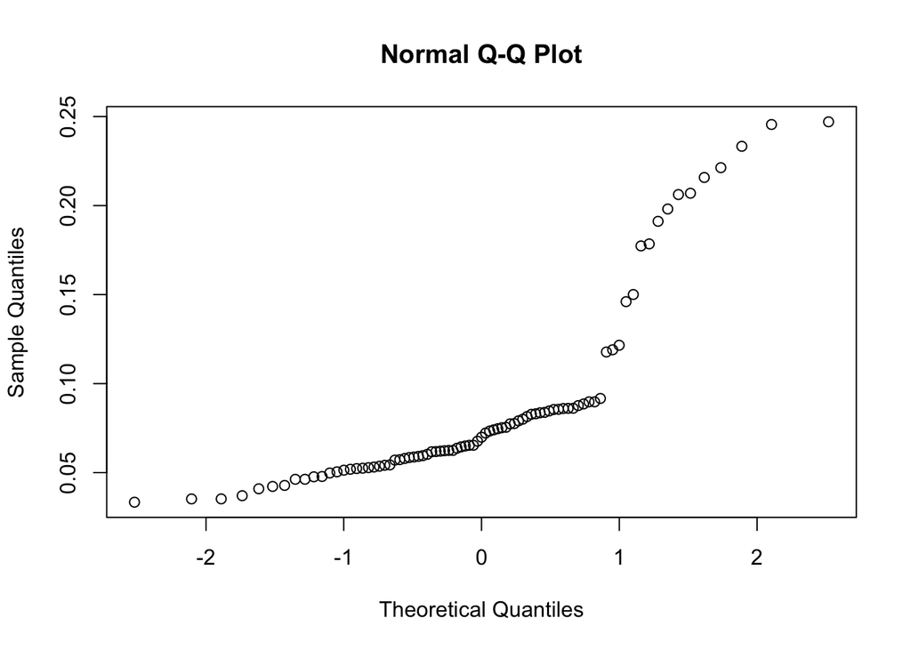

```r
qqnorm(cases_75up$prop)
```

```r
shapiro.test(cases_75up$prop)
```

```
##
##  Shapiro-Wilk normality test
##
## data:  cases_75up$prop
## W = 0.747, p-value = 8.549e-11
```

Better, but still not normal. Based on these results, run the appropriate two-sample test.

```r
wilcox.test(cases_25_34$prop, cases_75up$prop, paired = F)
```

```
##
##  Wilcoxon rank sum test with continuity correction
##
## data:  cases_25_34$prop and cases_75up$prop
## W = 5968, p-value = 2.144e-13
## alternative hypothesis: true location shift is not equal to 0
```

Is there a significant difference between the proportion of infections among 25-34 year-olds before and after the rise of the Delta strain? (Delta strain appeared 6/21/21.)

-check for normality and choose the appropriate test

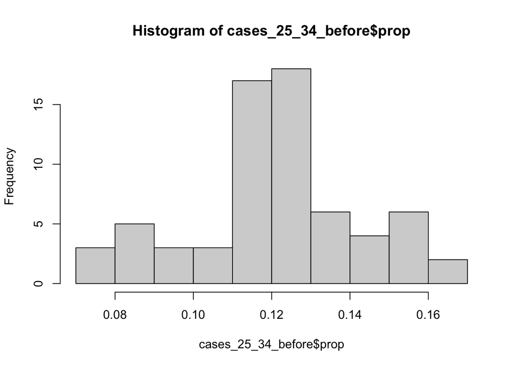

```r
cases_25_34<- cases_25_34%>%
  mutate(Delta= ifelse(week_ending < "0021-06-26", "Before Delta", "After Delta"))

cases_25_34_before <- cases_25_34 %>%
  filter(Delta == "Before Delta")

cases_25_34_after <- cases_25_34 %>%
  filter(Delta == "After Delta")

hist(cases_25_34_before$prop)
```

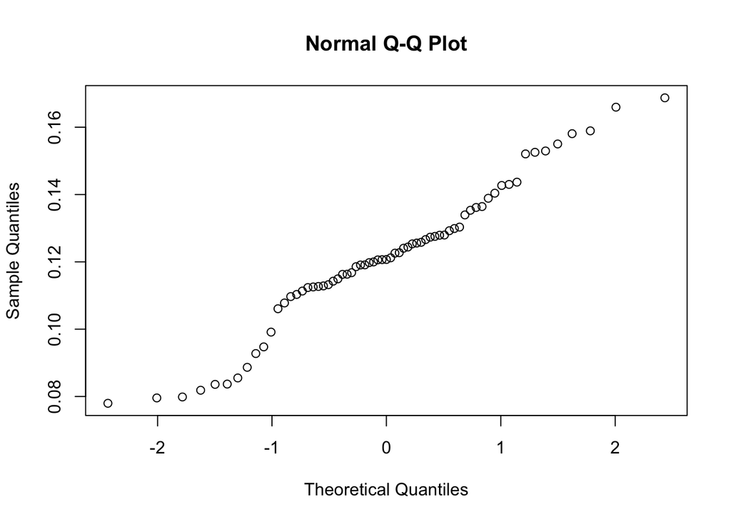

```r
qqnorm(cases_25_34_before$prop)
```

```r
shapiro.test(cases_25_34_before$prop)
```

```
##
##  Shapiro-Wilk normality test
##
## data:  cases_25_34_before$prop
## W = 0.96796, p-value = 0.08131
```

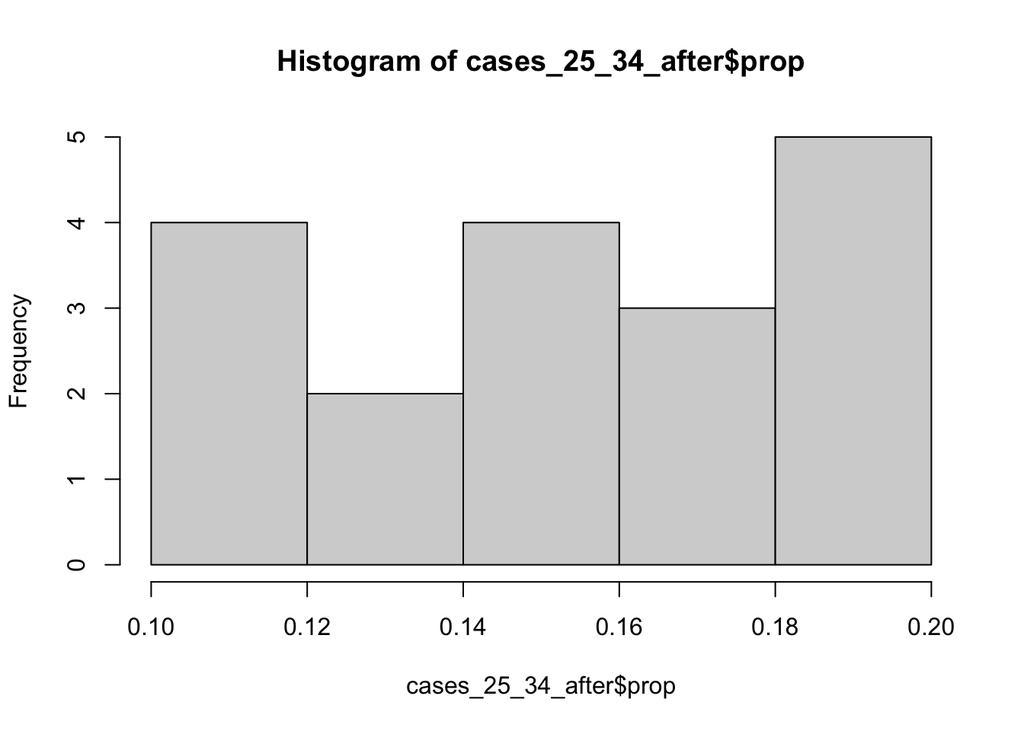

```r
hist(cases_25_34_after$prop)
```

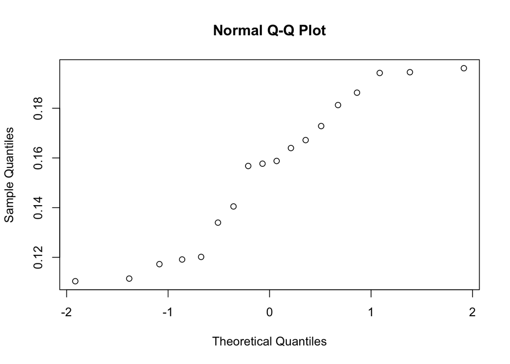

```r
qqnorm(cases_25_34_after$prop)
```

```r
shapiro.test(cases_25_34_after$prop)
```

```
##
##  Shapiro-Wilk normality test
##
## data:  cases_25_34_after$prop
## W = 0.91588, p-value = 0.1093
```

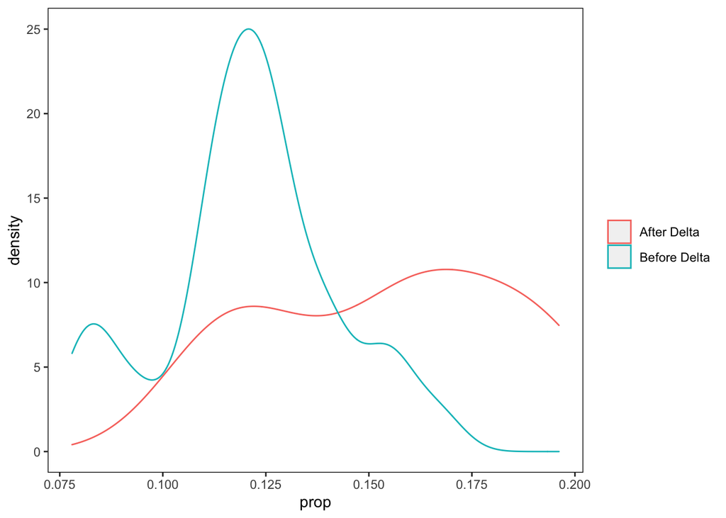

```r
cases_before_after_delta_plot<- ggplot(cases_25_34, aes(x=prop, color= Delta,
                                                        group= Delta))+
  geom_density() +
  theme(panel.background=element_blank(),
        strip.background = element_blank(),
        strip.placement = "outside",
        strip.text=element_blank(),
        panel.border=element_rect(colour="black",fill=NA),
        legend.title = element_blank())
cases_before_after_delta_plot
```

```r
t.test(cases_25_34_before$prop, cases_25_34_after$prop)
```

```
##
##  Welch Two Sample t-test
##
## data:  cases_25_34_before$prop and cases_25_34_after$prop
## t = -4.3942, df = 21.739, p-value = 0.0002359
## alternative hypothesis: true difference in means is not equal to 0
## 95 percent confidence interval:
##  -0.04900990 -0.01756674
## sample estimates:
## mean of x mean of y
## 0.1212920 0.1545803
```

#Chi Square and fishers exact test  
Consider the following data of the number of NYC documented Covid cases, hospitalizations, and deaths among vaccinated and unvaccinated individuals:

Cases: vaccinated: 820 unvaccinated: 4140

Hospitalizations: vaccinated: 32 unvaccinated: 349

Deaths: vaccinated: 4 unvaccinated: 39

Use this data to create a contingency table, and then perform the appropriate test to determine whether there is a significant difference between the vaccinated and unvaccinated groups.

```r
vaccinated<- c(820,32,4)
unvaccinated<- c(4140,349,39)

breakthrough<- data.frame(vaccinated, unvaccinated)
rownames(breakthrough)<- c("cases", "hospitalizations", "deaths")

chisq.test(breakthrough)
```

```
##
##  Pearson's Chi-squared test
##
## data:  breakthrough
## X-squared = 18.915, df = 2, p-value = 7.81e-05
```